# Complete Source Code for 2013 phyloseq Manuscript

## 3 plot_ordination - taxa only

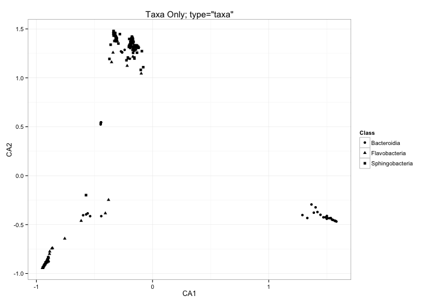

```r
p3 = plot_ordination(gpsfb, GP.ca, "taxa", shape="Class", title="Taxa Only; type=\"taxa\"")
p3
```

Separate the data into panels by taxonomic class of each OTU by adding a facet layer using the `facet_wrap` function.

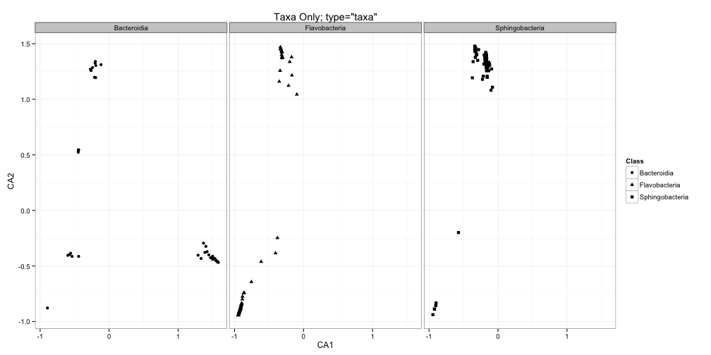

```r
p3 = p3 + facet_wrap(~Class, nrow = 1)
p3
```

Add a layer with larger-sized points using `geom_point`. It will use the default aesthetic mapping and data when invoked like this.

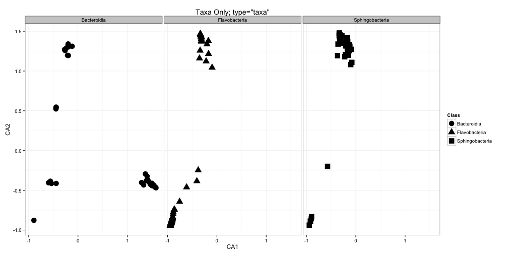

```r
p3 = p3 + geom_point(size = 5)
p3
```

Remove the original point layer that had small-sized points.

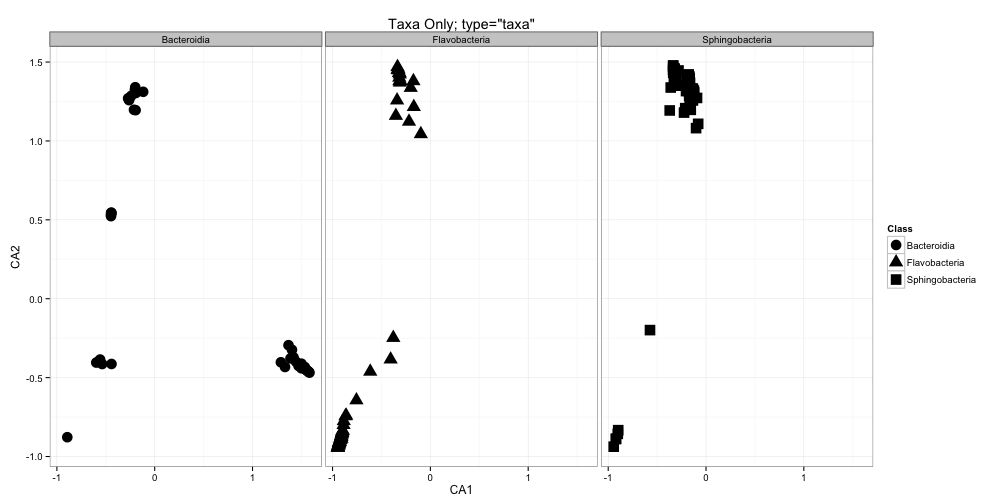

```r
p3$layers = p3$layers[-1]
p3
```

Manually define the shape scale that you want to use (as in, which shapes, and which order).

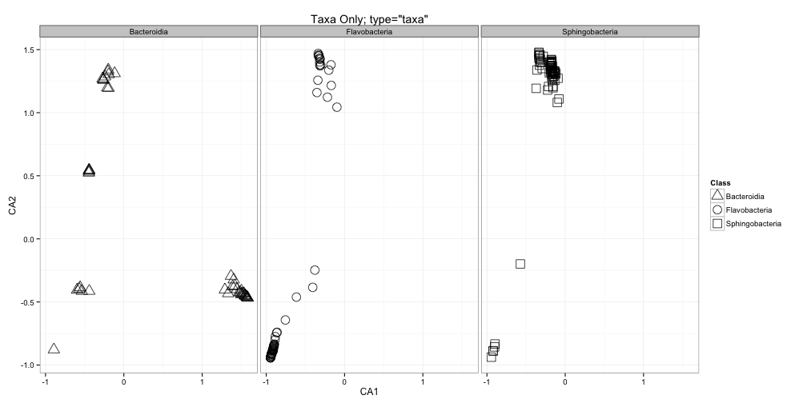

```r
p3 = p3 + scale_shape_manual(values = shape_scale)
p3
```

Add the 2-D density estimation.

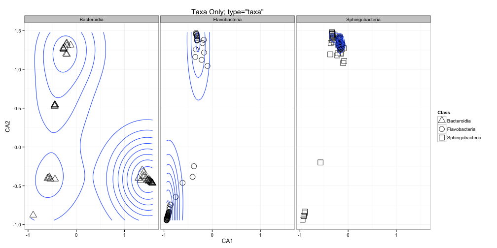

```r
p3 = p3 + geom_density2d()
p3
```

## 4 plot_ordination - split plot

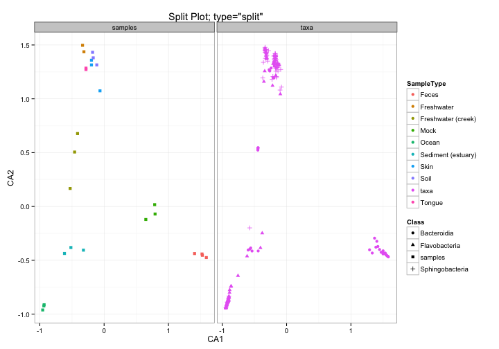

```r
p4 = plot_ordination(gpsfb, GP.ca, "split", color="SampleType", shape="Class", title="Split Plot; type=\"split\"")
p4
```

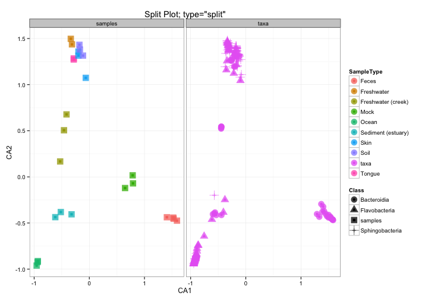

```r
p4 = p4 + geom_point(size = 5, alpha = alpha)
p4
```

Remove the original smaller-point-size layer

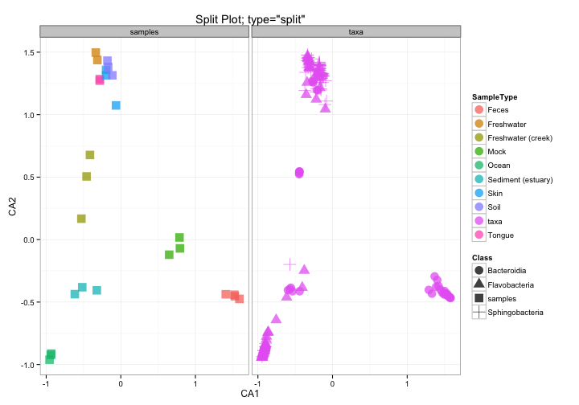

```r
p4$layers = p4$layers[-1]
p4
```

Set color scales to manual, `color_pal`

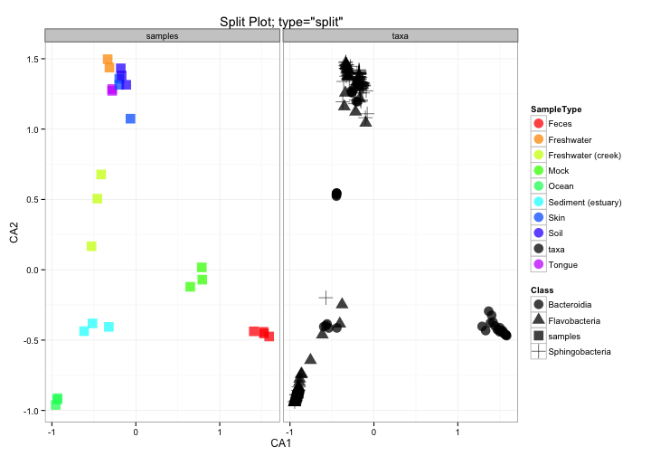

```r
p4 = p4 + scale_colour_manual(values = color_pal) + scale_fill_manual(values = color_pal)
p4
```

Re-order the color elements in legend.

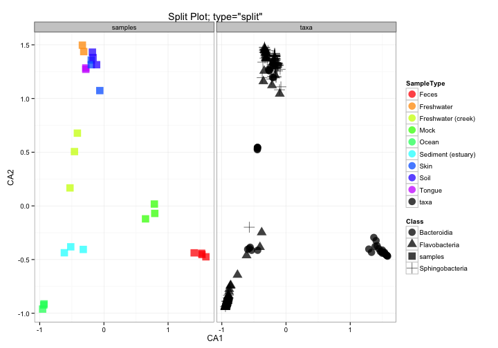

```r
stleg = as(p4$data$SampleType, "character")
stleg = factor(stleg, levels = c(levels(get_variable(gpsfb, "SampleType")),
    "taxa"))
p4$data$SampleType = stleg
p4
```

Re-order the shape elements in legend.

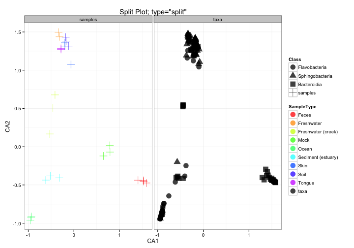

```r
cleg = as(p4$data$Class, "character")
cleg = factor(cleg, levels = c(unique(cleg[cleg != "samples"]), "samples"))
p4$data$Class = cleg
p4
```

Adjust the shape values

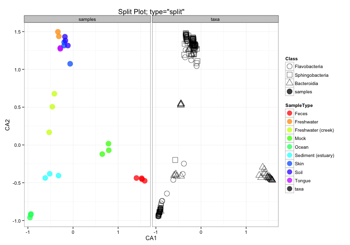

```r
p4 = p4 + scale_shape_manual(values = shape_scale)
p4
```

## Create combined ordination graphic

Requires the grid package. First test it out and embed in this tutorial page.

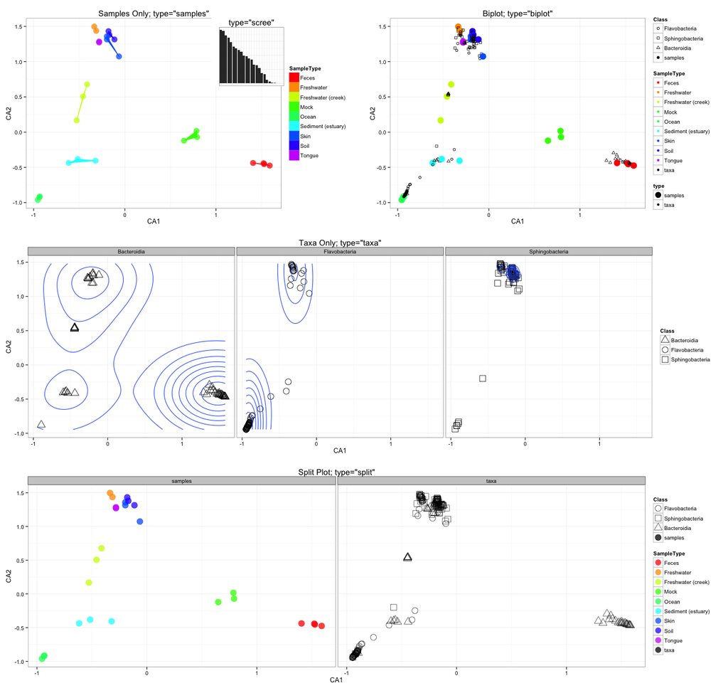

```r
grid.newpage()
pushViewport(viewport(layout = grid.layout(3, 2)))
print(p1, vp = viewport(layout.pos.row = 1, layout.pos.col = 1))
print(p2, vp = viewport(layout.pos.row = 1, layout.pos.col = 2))
print(p3, vp = viewport(layout.pos.row = 2, layout.pos.col = 1:2))
print(p4, vp = viewport(layout.pos.row = 3, layout.pos.col = 1:2))
# Add the scree plot to the first ordination plot, `p1`
subvp <- viewport(width = 0.1, height = 0.1, x = 0.34, y = 0.925)
print(p0, vp = subvp)
```

```r
# Close the device.
dev.off()
```

Now send the same graphics to a PDF file for publication, by bracing the previous graphics commands with `pdf()` and `dev.off()` commands.

```r
pdf(paste(main_figure_dir_name, "phyloseq-plot-ordination.pdf", sep = "/"),
    width = 18, height = 17)
grid.newpage()
pushViewport(viewport(layout = grid.layout(3, 2)))
print(p1, vp = viewport(layout.pos.row = 1, layout.pos.col = 1))
print(p2, vp = viewport(layout.pos.row = 1, layout.pos.col = 2))
print(p3, vp = viewport(layout.pos.row = 2, layout.pos.col = 1:2))
print(p4, vp = viewport(layout.pos.row = 3, layout.pos.col = 1:2))
# Add the scree plot to the first ordination plot, `p1`
subvp <- viewport(width = 0.1, height = 0.1, x = 0.34, y = 0.925)
print(p0, vp = subvp)
# Close the device.
dev.off()
```

# Using phyloseq data in other packages

Example porting data represented by the phyloseq-class for use in other packages, in this case [the vegan package](http://vegan.r-forge.r-project.org/).

```r
library("vegan")
packageVersion("vegan")
```

```
## [1] '2.0.6'
```

Define a function for extracting the OTU table from a phyloseq object and coercing it into a matrix class oriented in a way that vegan functions expect.

```r
veganotu <- function(physeq) {
    OTU <- otu_table(physeq)
    if (taxa_are_rows(OTU)) {
        OTU <- t(OTU)
    }
    return(as(OTU, "matrix"))
}
```

Now reload the `enterotype` dataset.

```r
data("enterotype")
```

Need to identify continuous variables

```r
keepvariables = which(sapply(sample_data(enterotype), is.numeric))
print(keepvariables)
```

```
## Age
##   8
```

```r
ent <- data.frame(sample_data(enterotype))[keepvariables]
```

Well, that's only one continuous variable, so let's add some simulated continuous variables to make this slightly more interesting.

```r
sim1 = sample(seq(0, 1, 0.02), nsamples(enterotype), TRUE)
sim2 = sample(seq(0, 1, 0.02), nsamples(enterotype), TRUE)
```

Add these simulated variables to sample-data

```r
ent$sim1 = sim1
ent$sim2 = sim2
```

Since there were ages missing, let's simulate those missing ages, too

```r
ent$Age[is.na(ent$Age)] = sample(1:92, sum(is.na(ent$Age)), TRUE)
```

Now try the vegan function, `bioenv`

```r
bioenv(veganotu(enterotype), ent)
```

```
##
## Call:
## bioenv(comm = veganotu(enterotype), env = ent)
##
## Subset of environmental variables with best correlation to community data.
##
## Correlations:      spearman
## Dissimilarities:   bray
##
## Best model has 2 parameters (max. 3 allowed):
## Age sim1
## with correlation  0.01975
```